# ML Frequency Domain

# Predicting Condition

We use downsampling to balance the cases. We set up a number of different models:

- There are 7 data subsets, 1 for each frequency domain section and 1 extra using the frequency domain portion with the significantly different predictors according to the non-parametric test.
- For each data subset, we predict condition using Logistic regression, XGBoost, RandomForest, SVM, and a basic Neural Network. We use 4 fold cross validation, which is to say, for each model, we split the data into 4 parts, and use 3 portions of the data to build a model, and the remaining quarter portion to test the model and calculate accuracy metrics. These accuracy metrics are then averaged over the 4 folds.

Below the data is shown:

```r
#how much data is available in each section?
features_output = read.csv("../DataOutputs/dat_out20181009.csv")%>%
  as.tibble()
features_output%>%
  filter(ID %in% pp)%>%
  #filter(!(Stress > 4 & Y == "Control"))%>% #filter high stress
  select(Avg_niHR:LFHF_6)%>%
  summarise_at(.vars = vars(Avg_niHR:LFHF_6), funs(sum(!is.na(.))))%>%
  gather("variable", "Rows")%>%
  arrange(-Rows)
```

| variable | Rows |
| --- | --- |
| Avg_niHR | 940 |
| Start_niHR | 940 |
| End_niHR | 940 |
| Avg_HR | 940 |
| HF_2 | 397 |
| LF_2 | 397 |
| LFHF_2 | 397 |
| HF_3 | 396 |
| LF_3 | 396 |
| LFHF_3 | 396 |

[output cut: 12 more lines]

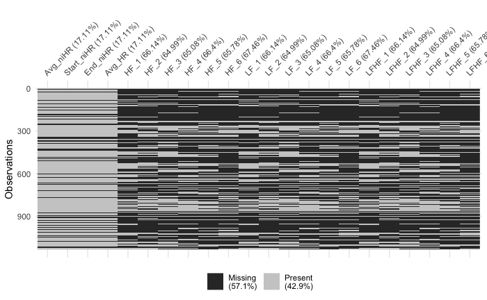

```r
features_output%>%
  filter(ID %in% pp)%>%
  #filter(!(Stress > 4 & Y == "Control"))%>% #filter high stress
  select(Avg_niHR:LFHF_6)%>%
  naniar::vis_miss()
```

The datasets change size once we start subsetting by variable to build multiple models.

# Machine Learning

## Setup

A glimpse at the dataset: for each of these 7 sets, we split 4 folds and calculate aggregate accuracy metrics.

```r
lapply(datasets, function(x) summary(x$data))
```

```
[[1]]
     Class       Avg_niHR        Start_niHR        End_niHR
 Control:64   Min.   : 49.94   Min.   : 52.60   Min.   : 48.00
 Episode:64   1st Qu.: 71.10   1st Qu.: 72.45   1st Qu.: 71.11
              Median : 78.56   Median : 80.00   Median : 80.00
              Mean   : 78.80   Mean   : 81.62   Mean   : 81.56
              3rd Qu.: 86.61   3rd Qu.: 89.30   3rd Qu.: 91.42
              Max.   :121.13   Max.   :159.99   Max.   :137.14
     Avg_HR            HF_1              LF_1           LFHF_1
 Min.   : 47.60   Min.   :  80.00   Min.   :101.0   Min.   : 1.000
 1st Qu.: 70.32   1st Qu.:  89.95   1st Qu.:101.0   1st Qu.: 2.300
 Median : 77.83   Median : 153.57   Median :226.1   Median : 3.717
 Mean   : 78.45   Mean   : 279.50   Mean   :324.6   Mean   : 4.759
 3rd Qu.: 85.87   3rd Qu.: 241.44   3rd Qu.:444.7   3rd Qu.: 6.593
 Max.   :123.57   Max.   :3630.00   Max.   :993.1   Max.   :12.000

[[2]]
     Class       Avg_niHR        Start_niHR        End_niHR
 Control:61   Min.   : 54.35   Min.   : 48.00   Min.   : 56.47
 Episode:61   1st Qu.: 71.72   1st Qu.: 73.84   1st Qu.: 72.45
              Median : 81.87   Median : 83.47   Median : 80.00
              Mean   : 79.81   Mean   : 85.31   Mean   : 81.68
              3rd Qu.: 87.00   3rd Qu.: 93.10   3rd Qu.: 89.30
              Max.   :100.58   Max.   :174.54   Max.   :137.14
     Avg_HR            HF_2              LF_2           LFHF_2
 Min.   : 54.79   Min.   :  80.00   Min.   :101.0   Min.   : 1.000
 1st Qu.: 70.99   1st Qu.:  99.67   1st Qu.:190.0   1st Qu.: 1.821
 Median : 80.58   Median : 155.03   Median :247.6   Median : 3.130
 Mean   : 79.65   Mean   : 228.59   Mean   :332.1   Mean   : 4.663
 3rd Qu.: 88.09   3rd Qu.: 262.83   3rd Qu.:476.0   3rd Qu.: 7.015
 Max.   :101.72   Max.   :3630.00   Max.   :999.2   Max.   :12.000

[[3]]
     Class       Avg_niHR        Start_niHR        End_niHR
 Control:61   Min.   : 54.78   Min.   : 55.65   Min.   : 58.18
 Episode:61   1st Qu.: 71.75   1st Qu.: 72.45   1st Qu.: 72.45
              Median : 80.22   Median : 80.00   Median : 80.00
              Mean   : 79.21   Mean   : 82.33   Mean   : 81.74
              3rd Qu.: 86.54   3rd Qu.: 91.42   3rd Qu.: 89.30
              Max.   :100.58   Max.   :116.36   Max.   :137.14
```

[output cut: 56 more lines]

```
[[7]]
     Class       Avg_niHR         End_niHR          Avg_HR
 Control:45   Min.   : 54.78   Min.   : 53.33   Min.   : 54.84
 Episode:45   1st Qu.: 70.87   1st Qu.: 72.45   1st Qu.: 70.49
              Median : 80.27   Median : 80.00   Median : 79.83
              Mean   : 79.31   Mean   : 81.97   Mean   : 79.18
              3rd Qu.: 87.14   3rd Qu.: 91.42   3rd Qu.: 87.47
              Max.   :104.82   Max.   :106.66   Max.   :105.02
      HF_4             LF_3
 Min.   :  80.0   Min.   :101.0
 1st Qu.: 106.5   1st Qu.:101.0
 Median : 186.3   Median :260.3
 Mean   : 251.1   Mean   :304.2
 3rd Qu.: 269.4   3rd Qu.:423.6
 Max.   :3630.0   Max.   :843.6
```

# Results

## Significant Predictors (GLM)

In the GLM, which variables were significant predictors?

```r
mod = 1:7
lapply(model_fits, function(x) do.call(rbind, x$glm$summaries))%>%
  Map(cbind, ., Model=mod)%>%
  do.call(rbind, .)%>%
  filter(Significant != "Not Significant")
```

| Variable | Estimate | Std_Error | Z_Value | P_Value | Significant | Fold | Model |
| --- | --- | --- | --- | --- | --- | --- | --- |
| Start_niHR | -0.05104126 | 0.02413035 | -2.115231 | 0.034410239 | Significant | 1 | 2 |
| Avg_HR | 0.42186715 | 0.20492995 | 2.058592 | 0.039533344 | Significant | 2 | 2 |
| LFHF_3 | -0.21475347 | 0.08092941 | -2.653590 | 0.007964055 | Significant | 4 | 3 |
| End_niHR | 0.06300828 | 0.02703013 | 2.331039 | 0.019751315 | Significant | 1 | 4 |
| End_niHR | 0.05289101 | 0.02565246 | 2.061830 | 0.039223932 | Significant | 2 | 4 |
| End_niHR | 0.07246866 | 0.02834445 | 2.556714 | 0.010566604 | Significant | 3 | 4 |
| End_niHR | 0.09721577 | 0.03210432 | 3.028122 | 0.002460791 | Significant | 4 | 4 |
| Start_niHR | -0.05742627 | 0.02273429 | -2.525976 | 0.011537736 | Significant | 2 | 5 |
| End_niHR | 0.07344944 | 0.03481867 | 2.109484 | 0.034902791 | Significant | 2 | 5 |
| End_niHR | 0.06376035 | 0.03228760 | 1.974763 | 0.048295066 | Significant | 2 | 7 |

In summary:

As shown below:

```r
lapply(model_fits, function(x) do.call(rbind, x$glm$summaries))%>%
  Map(cbind, ., Model=mod)%>%
  do.call(rbind, .)%>%
  filter(Significant != "Not Significant")%>%
  group_by(Variable, Model)%>%
  count()%>%
  arrange(Model)
```

| Variable | Model | n |
| --- | --- | --- |
| Avg_HR | 2 | 1 |
| Start_niHR | 2 | 1 |
| LFHF_3 | 3 | 1 |
| End_niHR | 4 | 4 |
| End_niHR | 5 | 1 |
| Start_niHR | 5 | 1 |
| End_niHR | 7 | 1 |

## GLM Predictions

```r
fold = 1:4
glmResults = data.frame()
for(x in 1:length(model_fits)){

  glmResults = model_fits[[x]]$glm$predictions%>%
    Map(cbind, ., fold=fold)%>%
    do.call(rbind,.)%>%
    group_by(fold)%>%
    nest()%>%
    mutate(result=lapply(data, ExtractConfusionMatrix))%>%
    select(-data)%>%
    unnest()%>%
    select(-fold)%>%
    summarise_all(funs(mean))%>%
    mutate(model=x)%>%
    select(model, everything())%>%
    rbind(glmResults,.)
}
glmResults
```

| model | Sensitivity | Specificity | Pos Pred Value | Neg Pred Value | Precision | Recall | F1 | Prevalence | Detection Rate | Detection Prevalence | Balanced Accuracy |
| --- | --- | --- | --- | --- | --- | --- | --- | --- | --- | --- | --- |
| 1 | 0.5312500 | 0.4062500 | 0.4717909 | 0.4558081 | 0.4717909 | 0.5312500 | 0.4935204 | 0.5 | 0.2656250 | 0.5625000 | 0.4687500 |
| 2 | 0.4947917 | 0.5604167 | 0.5300366 | 0.5259191 | 0.5300366 | 0.4947917 | 0.5114333 | 0.5 | 0.2473958 | 0.4671875 | 0.5276042 |
| 3 | 0.5583333 | 0.5572917 | 0.5638889 | 0.5559641 | 0.5638889 | 0.5583333 | 0.5577278 | 0.5 | 0.2791667 | 0.5005208 | 0.5578125 |
| 4 | 0.5000000 | 0.5928309 | 0.5512821 | 0.5425267 | 0.5512821 | 0.5000000 | 0.5236253 | 0.5 | 0.2500975 | 0.4540580 | 0.5464154 |
| 5 | 0.5464286 | 0.4559524 | 0.4982026 | 0.5057589 | 0.4982026 | 0.5464286 | 0.5170830 | 0.5 | 0.2718596 | 0.5443350 | 0.5011905 |
| 6 | 0.5892857 | 0.4821429 | 0.5316863 | 0.5456105 | 0.5316863 | 0.5892857 | 0.5542070 | 0.5 | 0.2946429 | 0.5535714 | 0.5357143 |
| 7 | 0.4678030 | 0.5340909 | 0.4982517 | 0.5040210 | 0.4982517 | 0.4678030 | 0.4785173 | 0.5 | 0.2327075 | 0.4664032 | 0.5009470 |

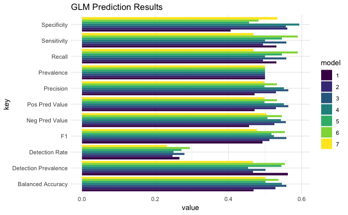

```r
glmResults%>%
  gather(key="key", value="value", -model)%>%
  mutate(model = as.factor(model))%>%
  ggplot(aes(x=key,y=value))+
  geom_bar(aes(fill=model), stat = "identity", position="dodge")+
  coord_flip()+
  theme_minimal()+
  labs(title = "GLM Prediction Results")+
  scale_fill_viridis(discrete=T)
```

## Random Forest Results

```r
rfResults = data.frame()
for(x in 1:length(model_fits)){

  rfResults = model_fits[[x]]$rf$predictions%>%
    Map(cbind, ., fold=fold)%>%
    do.call(rbind,.)%>%
    group_by(fold)%>%
    nest()%>%
    mutate(result=lapply(data, ExtractConfusionMatrix))%>%
    select(-data)%>%
    unnest()%>%
    select(-fold)%>%
    summarise_all(funs(mean))%>%
    mutate(model=x)%>%
    select(model, everything())%>%
    rbind(rfResults,.)
}
rfResults
```

| model | Sensitivity | Specificity | Pos Pred Value | Neg Pred Value | Precision | Recall | F1 | Prevalence | Detection Rate | Detection Prevalence | Balanced Accuracy |
| --- | --- | --- | --- | --- | --- | --- | --- | --- | --- | --- | --- |
| 1 | 0.4531250 | 0.5781250 | 0.5147665 | 0.5166301 | 0.5147665 | 0.4531250 | 0.4809626 | 0.5 | 0.2265625 | 0.4375000 | 0.5156250 |
| 2 | 0.6270833 | 0.6572917 | 0.6390541 | 0.6467063 | 0.6390541 | 0.6270833 | 0.6310704 | 0.5 | 0.3135417 | 0.4848958 | 0.6421875 |
| 3 | 0.5583333 | 0.5718750 | 0.5788462 | 0.5502924 | 0.5788462 | 0.5583333 | 0.5627988 | 0.5 | 0.2791667 | 0.4932292 | 0.5651042 |
| 4 | 0.5579044 | 0.5349265 | 0.5553832 | 0.5354663 | 0.5553832 | 0.5579044 | 0.5465819 | 0.5 | 0.2790497 | 0.5121853 | 0.5464154 |
| 5 | 0.5785714 | 0.5285714 | 0.5533613 | 0.5535714 | 0.5533613 | 0.5785714 | 0.5647465 | 0.5 | 0.2894089 | 0.5258621 | 0.5535714 |
| 6 | 0.5535714 | 0.4464286 | 0.4826389 | 0.5125000 | 0.4826389 | 0.5535714 | 0.5048240 | 0.5 | 0.2767857 | 0.5535714 | 0.5000000 |
| 7 | 0.4678030 | 0.3522727 | 0.4365079 | 0.3622489 | 0.4365079 | 0.4678030 | 0.4477425 | 0.5 | 0.2332016 | 0.5553360 | 0.4100379 |

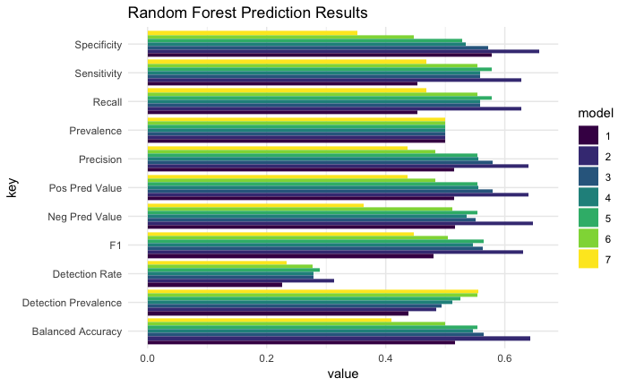

```r
rfResults%>%
  gather(key="key", value="value", -model)%>%
  mutate(model = as.factor(model))%>%
  ggplot(aes(x=key,y=value))+
  geom_bar(aes(fill=model), stat = "identity", position="dodge")+
  coord_flip()+
  theme_minimal()+
  labs(title = "Random Forest Prediction Results")+
  scale_fill_viridis(discrete=T)
```

## XGBoost Results

```r
xgbResults = data.frame()
for(x in 1:length(model_fits)){

  xgbResults = model_fits[[x]]$xgb$predictions%>%
    Map(cbind, ., fold=fold)%>%
    do.call(rbind,.)%>%
    group_by(fold)%>%
    nest()%>%
    mutate(result=lapply(data, ExtractConfusionMatrix))%>%
    select(-data)%>%
    unnest()%>%
    select(-fold)%>%
    summarise_all(funs(mean))%>%
    mutate(model=x)%>%
    select(model, everything())%>%
    rbind(xgbResults,.)
}
xgbResults
```

| model | Sensitivity | Specificity | Pos Pred Value | Neg Pred Value | Precision | Recall | F1 | Prevalence | Detection Rate | Detection Prevalence | Balanced Accuracy |
| --- | --- | --- | --- | --- | --- | --- | --- | --- | --- | --- | --- |
| 1 | 0.50000000 | 0.5000000 | NaN | NaN | NA | 0.50000000 | NA | 0.5 | 0.25000000 | 0.50000000 | 0.5000000 |
| 2 | 0.08333333 | 0.9500000 | NaN | 0.5113636 | NA | 0.08333333 | NA | 0.5 | 0.04166667 | 0.06666667 | 0.5166667 |
| 3 | 0.35000000 | 0.6333333 | NaN | NaN | NA | 0.35000000 | NA | 0.5 | 0.17500000 | 0.35833333 | 0.4916667 |
| 4 | 0.62132353 | 0.3952206 | 0.5100877 | 0.5044872 | 0.5100877 | 0.62132353 | 0.5575397 | 0.5 | 0.31144162 | 0.61508467 | 0.5082721 |
| 5 | 0.16071429 | 0.8214286 | NaN | 0.4861111 | NA | 0.16071429 | NA | 0.5 | 0.08035714 | 0.16964286 | 0.4910714 |
| 6 | 0.62500000 | 0.2678571 | 0.4000000 | NaN | 0.4000000 | 0.62500000 | 0.4630974 | 0.5 | 0.31250000 | 0.67857143 | 0.4464286 |
| 7 | 0.50000000 | 0.5000000 | NaN | NaN | NA | 0.50000000 | NA | 0.5 | 0.24456522 | 0.50000000 | 0.5000000 |

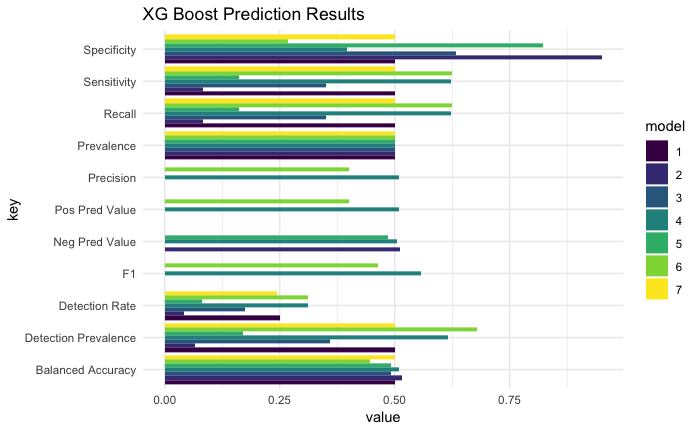

```r
xgbResults%>%
  gather(key="key", value="value", -model)%>%
  mutate(model = as.factor(model))%>%
  ggplot(aes(x=key,y=value))+
  geom_bar(aes(fill=model), stat = "identity", position="dodge")+
  coord_flip()+
  theme_minimal()+
  labs(title = "XG Boost Prediction Results")+
  scale_fill_viridis(discrete=T)
```

## SVM Results

```r
svmResults = data.frame()
for(x in 1:length(model_fits)){

  svmResults = model_fits[[x]]$svm$predictions%>%
    Map(cbind, ., fold=fold)%>%
    do.call(rbind,.)%>%
    group_by(fold)%>%
    nest()%>%
    mutate(result=lapply(data, ExtractConfusionMatrix))%>%
    select(-data)%>%
    unnest()%>%
    select(-fold)%>%
    summarise_all(funs(mean))%>%
    mutate(model=x)%>%
    select(model, everything())%>%
    rbind(svmResults,.)
}
svmResults
```

| model | Sensitivity | Specificity | Pos Pred Value | Neg Pred Value | Precision | Recall | F1 | Prevalence | Detection Rate | Detection Prevalence | Balanced Accuracy |
| --- | --- | --- | --- | --- | --- | --- | --- | --- | --- | --- | --- |
| 1 | 0.6250000 | 0.4062500 | 0.5105818 | 0.5263889 | 0.5105818 | 0.6250000 | 0.5601890 | 0.5 | 0.31250000 | 0.6093750 | 0.5156250 |
| 2 | 0.5072917 | 0.5093750 | 0.5118778 | 0.5050905 | 0.5118778 | 0.5072917 | 0.5073529 | 0.5 | 0.25364583 | 0.4989583 | 0.5083333 |
| 3 | 0.5739583 | 0.5427083 | 0.5638889 | 0.5569444 | 0.5638889 | 0.5739583 | 0.5653496 | 0.5 | 0.28697917 | 0.5156250 | 0.5583333 |
| 4 | 0.4715074 | 0.6525735 | 0.5807765 | 0.5522412 | 0.5807765 | 0.4715074 | 0.5159627 | 0.5 | 0.23564227 | 0.4102050 | 0.5620404 |
| 5 | 0.5940476 | 0.3880952 | 0.4886905 | 0.4960317 | 0.4886905 | 0.5940476 | 0.5321429 | 0.5 | 0.29710591 | 0.6034483 | 0.4910714 |
| 6 | 0.4107143 | 0.5714286 | 0.4750000 | 0.5045322 | 0.4750000 | 0.4107143 | 0.4307065 | 0.5 | 0.20535714 | 0.4196429 | 0.4910714 |
| 7 | 0.1818182 | 0.7765152 | NaN | 0.4849498 | NA | 0.1818182 | NA | 0.5 | 0.08942688 | 0.2020751 | 0.4791667 |

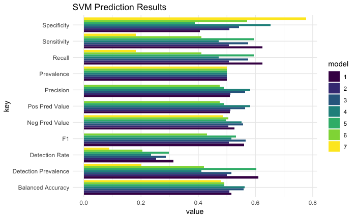

```r
svmResults%>%
  gather(key="key", value="value", -model)%>%
  mutate(model = as.factor(model))%>%
  ggplot(aes(x=key,y=value))+
  geom_bar(aes(fill=model), stat = "identity", position="dodge")+
  coord_flip()+
  theme_minimal()+
  labs(title = "SVM Prediction Results")+
  scale_fill_viridis(discrete=T)
```

## NeuralNetwork Results

```r
nnResults = data.frame()
for(x in 1:length(model_fits)){

  nnResults = model_fits[[x]]$nn$predictions%>%
    Map(cbind, ., fold=fold)%>%
    do.call(rbind,.)%>%
    group_by(fold)%>%
    nest()%>%
    mutate(result=lapply(data, ExtractConfusionMatrix))%>%
    select(-data)%>%
    unnest()%>%
    select(-fold)%>%
    summarise_all(funs(mean))%>%
    mutate(model=x)%>%
    select(model, everything())%>%
    rbind(nnResults,.)
}
nnResults
```

| model | Sensitivity | Specificity | Pos Pred Value | Neg Pred Value | Precision | Recall | F1 | Prevalence | Detection Rate | Detection Prevalence | Balanced Accuracy |
| --- | --- | --- | --- | --- | --- | --- | --- | --- | --- | --- | --- |
| 1 | 0.4375000 | 0.6250000 | 0.5280303 | 0.5313535 | 0.5280303 | 0.4375000 | 0.4743245 | 0.5 | 0.2187500 | 0.4062500 | 0.5312500 |
| 2 | 0.5031250 | 0.5760417 | NaN | 0.5666667 | NA | 0.5031250 | NA | 0.5 | 0.2515625 | 0.4635417 | 0.5395833 |
| 3 | 0.6052083 | 0.4135417 | 0.5111111 | 0.4997024 | 0.5111111 | 0.6052083 | 0.5509409 | 0.5 | 0.3026042 | 0.5958333 | 0.5093750 |
| 4 | 0.4678309 | 0.5818015 | 0.5365789 | 0.5309409 | 0.5365789 | 0.4678309 | 0.4616402 | 0.5 | 0.2326621 | 0.4425830 | 0.5248162 |
| 5 | 0.4630952 | 0.4738095 | 0.4666667 | 0.4665242 | 0.4666667 | 0.4630952 | 0.4114444 | 0.5 | 0.2296798 | 0.4947660 | 0.4684524 |
| 6 | 0.4821429 | 0.6607143 | 0.6077694 | 0.5663781 | 0.6077694 | 0.4821429 | 0.5086580 | 0.5 | 0.2410714 | 0.4107143 | 0.5714286 |
| 7 | 0.6382576 | 0.2424242 | 0.4503205 | 0.3261905 | 0.4503205 | 0.6382576 | 0.5227752 | 0.5 | 0.3201581 | 0.6971344 | 0.4403409 |

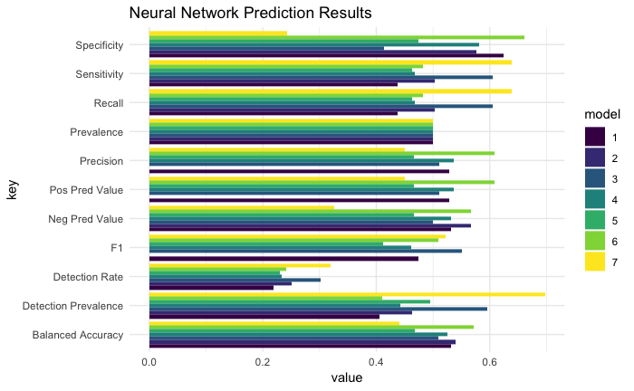

```r
nnResults%>%
  gather(key="key", value="value", -model)%>%
  mutate(model = as.factor(model))%>%
  ggplot(aes(x=key,y=value))+
  geom_bar(aes(fill=model), stat = "identity", position="dodge")+
  coord_flip()+
  theme_minimal()+
  labs(title = "Neural Network Prediction Results")+
  scale_fill_viridis(discrete=T)
```

# Conclusion

Overall, the best models are arranged by balanced accuracy below:

```r
method = c("GLM", "RandomForest", "XGBoost", "SVM", "NeuralNetwork")
Map(cbind, list(glmResults, rfResults, xgbResults, svmResults, nnResults), method = method)%>%
  do.call(rbind,.)%>%
  arrange(-`Balanced Accuracy`)
```

| model | Sensitivity | Specificity | Pos Pred Value | Neg Pred Value | Precision | Recall | F1 | Prevalence | Detection Rate | Detection Prevalence | Balanced Accuracy | method |
| --- | --- | --- | --- | --- | --- | --- | --- | --- | --- | --- | --- | --- |
| 2 | 0.62708333 | 0.6572917 | 0.6390541 | 0.6467063 | 0.6390541 | 0.62708333 | 0.6310704 | 0.5 | 0.31354167 | 0.48489583 | 0.6421875 | RandomForest |
| 6 | 0.48214286 | 0.6607143 | 0.6077694 | 0.5663781 | 0.6077694 | 0.48214286 | 0.5086580 | 0.5 | 0.24107143 | 0.41071429 | 0.5714286 | NeuralNetwork |
| 3 | 0.55833333 | 0.5718750 | 0.5788462 | 0.5502924 | 0.5788462 | 0.55833333 | 0.5627988 | 0.5 | 0.27916667 | 0.49322917 | 0.5651042 | RandomForest |
| 4 | 0.47150735 | 0.6525735 | 0.5807765 | 0.5522412 | 0.5807765 | 0.47150735 | 0.5159627 | 0.5 | 0.23564227 | 0.41020499 | 0.5620404 | SVM |
| 3 | 0.57395833 | 0.5427083 | 0.5638889 | 0.5569444 | 0.5638889 | 0.57395833 | 0.5653496 | 0.5 | 0.28697917 | 0.51562500 | 0.5583333 | SVM |
| 3 | 0.55833333 | 0.5572917 | 0.5638889 | 0.5559641 | 0.5638889 | 0.55833333 | 0.5577278 | 0.5 | 0.27916667 | 0.50052083 | 0.5578125 | GLM |
| 5 | 0.57857143 | 0.5285714 | 0.5533613 | 0.5535714 | 0.5533613 | 0.57857143 | 0.5647465 | 0.5 | 0.28940887 | 0.52586207 | 0.5535714 | RandomForest |
| 4 | 0.50000000 | 0.5928309 | 0.5512821 | 0.5425267 | 0.5512821 | 0.50000000 | 0.5236253 | 0.5 | 0.25009748 | 0.45405804 | 0.5464154 | GLM |
| 4 | 0.55790441 | 0.5349265 | 0.5553832 | 0.5354663 | 0.5553832 | 0.55790441 | 0.5465819 | 0.5 | 0.27904969 | 0.51218527 | 0.5464154 | RandomForest |
| 2 | 0.50312500 | 0.5760417 | NaN | 0.5666667 | NA | 0.50312500 | NA | 0.5 | 0.25156250 | 0.46354167 | 0.5395833 | NeuralNetwork |

[output cut: 25 more lines]